# EDA

Author

Affiliation

Jingda Yang

Georgetown University

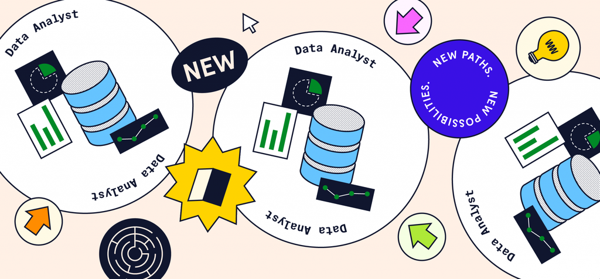

*Picture from codecademy*

**note**

**Please refresh the page if table or figure is not displayed.**  
**Please use Code option on the top right corner to see the code or hide the code.**  
**Please use the dark/light theme option on the top right corner to change the theme.**

# 1 Crypto Market Overview

From 2023 to 2024, the cryptocurrency market in the US experienced significant fluctuations. Bitcoin, Ethereum, and other major coins witnessed both surges and corrections in their prices. This period saw increased regulatory scrutiny, impacting market sentiment and prices. Additionally, the emergence of new projects and technologies contributed to market dynamics, with some coins experiencing rapid growth while others faced challenges or faded into obscurity. A market overview is crucial to understanding trends, assessing risk, and making informed investment decisions. It provides insights into market sentiment, regulatory developments, technological advancements, and the performance of various coins. With the crypto market being highly volatile and influenced by numerous factors, a comprehensive overview helps investors navigate this complex landscape and identify opportunities amidst the risks.

## 1.1 Dataset Overview

We utilize Kaggle data encompassing prices and trading volumes of various cryptocurrencies, supplemented by calculations for M20 and M5 metrics. The dataset spans from January 1, 2023, to recent data in 2024. Below, we present a succinct overview along with descriptive statistics of the variables.

# 2 Importing Necessary Libraries

```python
import os
import requests
import pandas as pd
import numpy as np
import datetime
pd.set_option('display.float_format',lambda x : '%.2f'%x)
import warnings
warnings.filterwarnings('ignore')
import plotly.graph_objects as go
import gc
import matplotlib.colors
from plotly.subplots import make_subplots
from plotly.offline import init_notebook_mode
from datetime import datetime, timedelta
from decimal import ROUND_HALF_UP, Decimal
import plotly.figure_factory as ff
```

# 3 Data Import and Preprocessing

```python
# Define the directory path
directory = '../data/historical_data2'

# Define the list of CSV files to import
csv_files = [
    'bitcoin.csv',
    'ethereum.csv',
    'ethereum-classic.csv',
    'binancecoin.csv',
    'bitcoin-cash.csv',
    'solana.csv',
    'cardano.csv',
    'ripple.csv',
    'dogecoin.csv',

]

# Initialize an empty list to store dataframes
dfs = []

# Loop through the selected CSV files
for filename in csv_files:
    file_path = os.path.join(directory, filename)
    # Read each CSV file and append to the list
    df = pd.read_csv(file_path)

    # Convert 'date' column to datetime format
    df['date'] = pd.to_datetime(df['date'])

    # Convert columns with scientific notation to float
    df['total_volume'] = df['total_volume'].astype(float)
    df['market_cap'] = df['market_cap'].astype(float)

    dfs.append(df)

# Concatenate all dataframes in the list
df = pd.concat(dfs, ignore_index=False)
df.rename(columns={'total_volume': 'volume', 'coin_name': 'exchange'}, inplace=True)

# Convert date column to datetime
# Convert 'date' to datetime and sort
df['date'] = pd.to_datetime(df['date'])
df = df.sort_values(by=['exchange', 'date'])

# Calculating M20 and M5
df['M20'] = df.groupby('exchange')['price'].transform(lambda x: x.rolling(window=20).mean())
df['M5'] = df.groupby('exchange')['price'].transform(lambda x: x.rolling(window=5).mean())
df = df.dropna()

#drop all date before 2023
df = df[df['date'] >= '2023-01-01']
df2 = df.copy()
df.drop(columns=['market_cap'], inplace=True)
df.head()
```

Table 1: Raw Dataset

|  | date | price | volume | exchange | M20 | M5 |
| --- | --- | --- | --- | --- | --- | --- |
| 1931 | 2023-01-01 | 246.66 | 17764481.57 | binancecoin | 249.45 | 245.89 |
| 1932 | 2023-01-02 | 244.06 | 230405872.61 | binancecoin | 247.81 | 245.41 |
| 1933 | 2023-01-03 | 245.43 | 393346445.62 | binancecoin | 246.48 | 245.69 |
| 1934 | 2023-01-04 | 246.21 | 256645348.85 | binancecoin | 245.37 | 245.64 |
| 1935 | 2023-01-05 | 259.13 | 713673930.47 | binancecoin | 245.47 | 248.30 |

```python
ds=df.describe()
ds=pd.DataFrame(ds)
ds
```

Table 2: Descriptive Statistics of Dataset

|  | price | volume | M20 | M5 |
| --- | --- | --- | --- | --- |
| count | 4068.00 | 4068.00 | 4068.00 | 4068.00 |
| mean | 3991.01 | 4369191270.33 | 3865.05 | 3963.70 |
| std | 11112.62 | 9275163197.03 | 10679.59 | 11019.04 |
| min | 0.06 | 17764481.57 | 0.06 | 0.06 |
| 25% | 0.51 | 255958245.78 | 0.51 | 0.51 |
| 50% | 25.40 | 626872638.48 | 24.32 | 24.81 |
| 75% | 322.32 | 2953179859.87 | 316.19 | 319.61 |
| max | 73097.77 | 96403762012.66 | 68124.91 | 71522.66 |

# 4 Data Visualization - Crypto Price and Market Cap Over Time

```python
ex_data = df.copy()
market_cap = df2.copy()

# Define a color map for exchanges
color_map = {
    'bitcoin': '#FF9900',
    'ethereum': '#3C3C3D',
    'ethereum-classic': '#669073',
    'binancecoin': '#F3BA2F',
    'bitcoin-cash': '#4CC947',
    'solana': '#00FFCD',
    'cardano': '#3D9',
    'ripple': '#006097',
    'dogecoin': '#BA9F33',
}
# Create a figure with subplots
fig = make_subplots(rows=1, cols=2, subplot_titles=('Crypto Price Over Time', 'Market Cap Over Time'), shared_xaxes=True)

# Plot 1: Crypto Prices
for exchange in ex_data['exchange'].unique():
    fig.add_trace(
        go.Scatter(
            x=ex_data[ex_data['exchange'] == exchange]['date'],
            y=ex_data[ex_data['exchange'] == exchange]['price'],
            name=exchange,
            mode='lines',
            line=dict(color=color_map.get(exchange, 'black')),  # Use color map, default to black if not found
            legendgroup=exchange  # Assign to legend group
        ),
        row=1, col=1
    )

# Plot 2: Market Cap
for exchange in market_cap['exchange'].unique():
    fig.add_trace(
        go.Scatter(
            x=market_cap[market_cap['exchange'] == exchange]['date'],
            y=market_cap[market_cap['exchange'] == exchange]['market_cap'],
            name=exchange,
            mode='lines',
            line=dict(color=color_map.get(exchange, 'black')),  # Use color map
            legendgroup=exchange,  # Assign to the same legend group as the first plot
            showlegend=False  # Optionally disable legend duplication
        ),
        row=1, col=2
    )

# Update y-axes to use a logarithmic scale
fig.update_yaxes(title_text="Close Price (USD)", type="log", row=1, col=1)
fig.update_yaxes(title_text="Market Cap (USD)", type="log", row=1, col=2)

# Add range slider to each subplot
fig.update_layout(
    xaxis=dict(
        rangeselector=dict(
            buttons=list([
                dict(count=1, label="1m", step="month", stepmode="backward"),
                dict(count=6, label="6m", step="month", stepmode="backward"),
                dict(step="all")
            ])
        ),
        rangeslider=dict(visible=True),
        type="date"
    ),
    xaxis2=dict(
        rangeselector=dict(
            buttons=list([
                dict(count=1, label="1m", step="month", stepmode="backward"),
                dict(count=6, label="6m", step="month", stepmode="backward"),
                dict(step="all")
            ])
        ),
        rangeslider=dict(visible=True),
        type="date"
    ),
    title_text="Crypto Price and Market Cap Over Time", height=600, width=1200
)

fig.show()
```

[interactive chart not shown]

Figure 1: Crypto Price and Market Cap Over Time

**note**

Please double-click a coin on the right legend to isolate a specific cryptocurrency for better visualization.

The charts depict the price and market capitalization of various cryptocurrencies over time, plotted on logarithmic scales to accommodate wide-ranging values. Bitcoin has the highest price and market cap, with Ethereum following. Most cryptocurrencies show an increase in both price and market cap over the observed period. Market caps for smaller cryptocurrencies like Dogecoin, Ripple, and Cardano are lower but increase steadily. Ethereum Classic, Solana, and Binance Coin also show growth. The right charts indicate that while prices fluctuate, market caps generally trend upwards, suggesting an increasing investment in these assets over time. The growth trajectory is consistent across both short-term and long-term views.

# 5 Data Visualization - Correlation Heatmap of Cryptocurrencies

```python
df_pivot=df.pivot_table(index='date', columns='exchange', values='price').reset_index()
corr=df_pivot.corr().round(2)
mask=np.triu(np.ones_like(corr, dtype=bool))
c_mask = np.where(~mask, corr, 100)
c=[]
for i in c_mask.tolist()[1:]:
    c.append([x for x in i if x != 100])

cor=c[::-1]
x=corr.index.tolist()[:-1]
y=corr.columns.tolist()[1:][::-1]
fig=ff.create_annotated_heatmap(z=cor, x=x, y=y,
                                hovertemplate='Correlation between %{x} and %{y} Coin = %{z}',
                                colorscale='viridis', name='')
fig.update_layout(template="plotly_white", title='Coin Correlation',height=800,width=900,
                  yaxis=dict(showgrid=False, autorange='reversed'),
                  xaxis=dict(showgrid=False))
fig.show()
```

[interactive chart not shown]

Figure 2: Correlation Heatmap of Cryptocurrencies

The chart presents the correlation coefficients between various cryptocurrencies. Bitcoin shows a high correlation with most coins, particularly Ethereum at 0.97, suggesting their market movements are closely related. Ethereum Classic also shows strong correlations with other coins, especially Ethereum at 0.86. Dogecoin has a noticeable correlation with Bitcoin at 0.78 and even higher with Binance Coin at 0.86. Ripple stands out for its low correlation with other cryptocurrencies, notably only 0.04 with Binance Coin, indicating its price movements are mostly independent from the others. Generally, the chart reflects interdependencies between these digital assets, with Bitcoin being a central reference point.

# 6 Data Visualization - Average Return, Closing Price, and Shares Traded Over Time

```python
colors=['blue','red','green']
df["Return"] = df.groupby("exchange")["price"].pct_change(1)
train_date=df.date.unique()
returns=df.groupby('date')['Return'].mean().mul(100).rename('Average Return')
close_avg=df.groupby('date')['price'].mean().rename('Closing Price')
vol_avg=df.groupby('date')['volume'].mean().rename('Volume')

fig = make_subplots(rows=3, cols=1,
                    shared_xaxes=True)
for i, j in enumerate([returns, close_avg, vol_avg]):
    fig.add_trace(go.Scatter(x=train_date, y=j, mode='lines',
                             name=j.name, marker_color=colors[i]), row=i+1, col=1)
fig.update_xaxes(rangeslider_visible=False,
                 rangeselector=dict(
                     buttons=list([
                         dict(count=6, label="6m", step="month", stepmode="backward"),
                         dict(count=1, label="1y", step="year", stepmode="backward"),
                         dict(count=2, label="2y", step="year", stepmode="backward"),
                         dict(step="all")])),
                 row=1,col=1)
fig.update_layout(title='Average Stock Return, Average Closing Price, and Average Shares Traded',
                  hovermode='x unified', height=800,
                  yaxis1=dict(title='Average Coin Return (%)', ticksuffix='%'),
                  yaxis2_title='Average Closing Price (USD)', yaxis3_title='Average Shares Traded (USD)',
                  showlegend=False)
fig.show()
```

[interactive chart not shown]

Figure 3: Average Return, Closing Price, and Shares Traded Over Time

The composite chart displays the Market’s average coin return, closing price, and shares traded over time. The top graph shows fluctuating daily returns, mostly ranging between -10% and +10%, without a clear trend of increase or decrease, indicating volatility in returns. The middle graph illustrates the closing price of a cryptocurrency, which shows a steady increase over time, particularly a sharp rise around late 2023 through early 2024, suggesting significant price growth during this period. The bottom graph depicts the shares traded in USD, with notable spikes in trading volume at several points, especially a significant peak around March 2023 followed by generally increasing activity towards March 2024, reflecting heightened market activity at these times.

# 7 Data Visualization - Yearly Average Returns

```python
final_v1=df.copy()
final_v1["Return"] = final_v1.groupby("exchange")["price"].pct_change(1)
final_v1['date'] = pd.to_datetime(final_v1['date'],errors='coerce')
final_v1['Year'] = final_v1['date'].dt.year
years = {year: pd.DataFrame() for year in final_v1.Year.unique()[::-1]}
for key in years.keys():
    df=final_v1[final_v1.Year == key]
    years[key] = df.groupby('exchange')['Return'].mean().mul(100).rename("Avg_return_{}".format(key))
df=pd.concat((years[i].to_frame() for i in years.keys()), axis=1)
df=df.sort_values(by="Avg_return_2023")
fig = make_subplots(rows=1, cols=3, shared_yaxes=True)  # Adjust based on your actual subplot needs

for i, col in enumerate(df.columns):
    x = df[col]
    mask = x <= 0
    # Adding traces for negative and positive returns
    fig.add_trace(go.Bar(x=x[mask], y=df.index[mask], orientation='h',
                         text=x[mask], texttemplate='%{text:.2f}%', textposition='auto',
                         hovertemplate='Average Return in %{y} exchange = %{x:.4f}%',
                         marker=dict(color='red', opacity=0.7), name=col[-4:]),
                  row=1, col=i+1)
    fig.add_trace(go.Bar(x=x[~mask], y=df.index[~mask], orientation='h',
                         text=x[~mask], texttemplate='%{text:.2f}%', textposition='auto',
                         hovertemplate='Average Return in %{y} exchange = %{x:.4f}%',
                         marker=dict(color='green', opacity=0.7), name=col[-4:]),
                  row=1, col=i+1)

    # Update axes to include grid
    fig.update_xaxes(title_text=f"{col[-4:]} Returns", title_standoff=25,
                     automargin=True, showgrid=True, gridcolor='LightGrey', row=1, col=i+1)
    fig.update_yaxes(showgrid=True, gridcolor='LightGrey', row=1, col=i+1)

fig.update_layout(template="plotly_white", title='Yearly Average Returns',
                  hovermode='closest', height=600, width=900, showlegend=False)
fig.show()
```

[interactive chart not shown]

Figure 4: Yearly Average Returns

# 8 Conclusion

The cryptocurrency market in the US experienced significant fluctuations from 2023 to 2024, with Bitcoin, Ethereum, and other major coins witnessing both surges and corrections in their prices. The dataset analyzed in this overview provides insights into the market dynamics, including price movements, trading volumes, and correlations between various cryptocurrencies. The visualizations presented in this report offer a comprehensive view of the market, highlighting trends, patterns, and opportunities for investors. By examining the data and visualizations, investors can gain a better understanding of the market landscape, assess risks, and make informed investment decisions. The analysis underscores the importance of monitoring market trends, regulatory developments, and technological advancements to navigate the volatile cryptocurrency market successfully.